# Data Visualisation with ggplot2 Project Joseph Thiongo

# AfterWork Data Science: Data Visualisation with Python Project

## 1. Defining the Question

### a) Specifying the Data Analysis Question

To provide Hilton management with strategy recommendations that will lead to revenue growth.

### c) Understanding the context

I am a Data Scientist working for Hilton International Hotels and need to help the management decide on the strategies that will lead to revenue growth.

I have a dataset containing information on the various chain of hotels, including when customers made the booking, length of stay, the number of adults, children, or babies, and the number of available parking spaces, among other things.

Given this dataset, i will perform data exploration, data cleaning, and analysis to come with appropriate recommendations. As a start, while performing data analysis, i will ask the following questions from the given dataset. Making sure to have a visualization for each question. ● How many bookings were canceled? ● What was the booking ratio between resort hotels and city hotels? ● What was the percentage of booking for each year? ● Which was the busiest month for hotels? ● Most guests came from which country? ● How long do most people stay in hotels? ● Which was the most booked accommodation type (Single, Couple, Family)?

### d) Recording the Experimental Design

The steps to be taken include:

- Load dataset and preview its summarized information to get a feel of what i will be working with.
- Carry out data cleaning.
- Carry out data analysis.
- Interpret results.
- Provide recommendations based on results of analysis.
- Challenge your solution.

### e) Data Relevance

The dataset contains information regarding customer bookings which will aid our research analysis

## 2. Reading the Data

```r
install.packages("tidyverse", repos = "http://cran.us.r-project.org")
library("tidyverse")
# Load the data below
# ---
# Dataset url =
# ---
# YOUR CODE GOES BELOW
#

source_df <- read_csv("hotel_bookings.csv")
head(source_df)
```

```
## # A tibble: 6 × 32
##   hotel   is_ca…¹ lead_…² arriv…³ arriv…⁴ arriv…⁵ arriv…⁶ stays…⁷ stays…⁸ adults
##   <chr>     <dbl>   <dbl>   <dbl> <chr>     <dbl>   <dbl>   <dbl>   <dbl>  <dbl>
## 1 Resort…       0     342    2015 July         27       1       0       0      2
## 2 Resort…       0     737    2015 July         27       1       0       0      2
## 3 Resort…       0       7    2015 July         27       1       0       1      1
## 4 Resort…       0      13    2015 July         27       1       0       1      1
## 5 Resort…       0      14    2015 July         27       1       0       2      2
## 6 Resort…       0      14    2015 July         27       1       0       2      2
## # … with 22 more variables: children <dbl>, babies <dbl>, meal <chr>,
## #   country <chr>, market_segment <chr>, distribution_channel <chr>,
## #   is_repeated_guest <dbl>, previous_cancellations <dbl>,
## #   previous_bookings_not_canceled <dbl>, reserved_room_type <chr>,
## #   assigned_room_type <chr>, booking_changes <dbl>, deposit_type <chr>,
## #   agent <chr>, company <chr>, days_in_waiting_list <dbl>,
## #   customer_type <chr>, adr <dbl>, required_car_parking_spaces <dbl>, …
```

```r
# Checking the first 5 rows of data
# ---
# YOUR CODE GOES BELOW
#

head(source_df,5)
```

```
## # A tibble: 5 × 32
##   hotel   is_ca…¹ lead_…² arriv…³ arriv…⁴ arriv…⁵ arriv…⁶ stays…⁷ stays…⁸ adults
##   <chr>     <dbl>   <dbl>   <dbl> <chr>     <dbl>   <dbl>   <dbl>   <dbl>  <dbl>
## 1 Resort…       0     342    2015 July         27       1       0       0      2
## 2 Resort…       0     737    2015 July         27       1       0       0      2
## 3 Resort…       0       7    2015 July         27       1       0       1      1
## 4 Resort…       0      13    2015 July         27       1       0       1      1
## 5 Resort…       0      14    2015 July         27       1       0       2      2
## # … with 22 more variables: children <dbl>, babies <dbl>, meal <chr>,
## #   country <chr>, market_segment <chr>, distribution_channel <chr>,
## #   is_repeated_guest <dbl>, previous_cancellations <dbl>,
## #   previous_bookings_not_canceled <dbl>, reserved_room_type <chr>,
## #   assigned_room_type <chr>, booking_changes <dbl>, deposit_type <chr>,
## #   agent <chr>, company <chr>, days_in_waiting_list <dbl>,
## #   customer_type <chr>, adr <dbl>, required_car_parking_spaces <dbl>, …
```

```r
# Checking the last 5 rows of data
# ---
# YOUR CODE GOES BELOW
#
tail(source_df,5)
```

```
## # A tibble: 5 × 32
##   hotel   is_ca…¹ lead_…² arriv…³ arriv…⁴ arriv…⁵ arriv…⁶ stays…⁷ stays…⁸ adults
##   <chr>     <dbl>   <dbl>   <dbl> <chr>     <dbl>   <dbl>   <dbl>   <dbl>  <dbl>
## 1 City H…       0      23    2017 August       35      30       2       5      2
## 2 City H…       0     102    2017 August       35      31       2       5      3
## 3 City H…       0      34    2017 August       35      31       2       5      2
## 4 City H…       0     109    2017 August       35      31       2       5      2
## 5 City H…       0     205    2017 August       35      29       2       7      2
## # … with 22 more variables: children <dbl>, babies <dbl>, meal <chr>,
## #   country <chr>, market_segment <chr>, distribution_channel <chr>,
## #   is_repeated_guest <dbl>, previous_cancellations <dbl>,
## #   previous_bookings_not_canceled <dbl>, reserved_room_type <chr>,
## #   assigned_room_type <chr>, booking_changes <dbl>, deposit_type <chr>,
## #   agent <chr>, company <chr>, days_in_waiting_list <dbl>,
## #   customer_type <chr>, adr <dbl>, required_car_parking_spaces <dbl>, …
```

```r
# Sample 10 rows of data
# ---
# YOUR CODE GOES BELOW
#
sample_n(source_df,10)
```

```
## # A tibble: 10 × 32
##    hotel  is_ca…¹ lead_…² arriv…³ arriv…⁴ arriv…⁵ arriv…⁶ stays…⁷ stays…⁸ adults
##    <chr>    <dbl>   <dbl>   <dbl> <chr>     <dbl>   <dbl>   <dbl>   <dbl>  <dbl>
##  1 City …       1      56    2016 June         24       8       0       1      2
##  2 City …       0       0    2017 June         26      28       0       1      1
##  3 City …       1     393    2017 April        16      22       2       1      2
##  4 Resor…       1       6    2017 August       35      31       1       3      2
##  5 City …       1     129    2016 August       33      11       2       3      2
##  6 City …       1      72    2016 March        11       8       0       4      2
##  7 City …       0      79    2015 October      41      10       1       1      2
##  8 City …       0      40    2015 August       33      15       2       2      2
##  9 City …       1      14    2016 April        17      19       0       1      2
## 10 City …       1     250    2016 October      44      28       2       2      2
## # … with 22 more variables: children <dbl>, babies <dbl>, meal <chr>,
## #   country <chr>, market_segment <chr>, distribution_channel <chr>,
## #   is_repeated_guest <dbl>, previous_cancellations <dbl>,
## #   previous_bookings_not_canceled <dbl>, reserved_room_type <chr>,
## #   assigned_room_type <chr>, booking_changes <dbl>, deposit_type <chr>,
## #   agent <chr>, company <chr>, days_in_waiting_list <dbl>,
## #   customer_type <chr>, adr <dbl>, required_car_parking_spaces <dbl>, …
```

```r
# Checking number of rows and columns
# ---
# YOUR CODE GOES BELOW
#
dim(source_df)
```

```
## [1] 119390     32
```

```r
# Checking datatypes
# ---
# YOUR CODE GOES BELOW
#

str(source_df)
```

```
## spec_tbl_df [119,390 × 32] (S3: spec_tbl_df/tbl_df/tbl/data.frame)
##  $ hotel                         : chr [1:119390] "Resort Hotel" "Resort Hotel" "Resort Hotel" "Resort Hotel" ...
##  $ is_canceled                   : num [1:119390] 0 0 0 0 0 0 0 0 1 1 ...
##  $ lead_time                     : num [1:119390] 342 737 7 13 14 14 0 9 85 75 ...
##  $ arrival_date_year             : num [1:119390] 2015 2015 2015 2015 2015 ...
##  $ arrival_date_month            : chr [1:119390] "July" "July" "July" "July" ...
##  $ arrival_date_week_number      : num [1:119390] 27 27 27 27 27 27 27 27 27 27 ...
##  $ arrival_date_day_of_month     : num [1:119390] 1 1 1 1 1 1 1 1 1 1 ...
##  $ stays_in_weekend_nights       : num [1:119390] 0 0 0 0 0 0 0 0 0 0 ...
##  $ stays_in_week_nights          : num [1:119390] 0 0 1 1 2 2 2 2 3 3 ...
##  $ adults                        : num [1:119390] 2 2 1 1 2 2 2 2 2 2 ...
##  $ children                      : num [1:119390] 0 0 0 0 0 0 0 0 0 0 ...
##  $ babies                        : num [1:119390] 0 0 0 0 0 0 0 0 0 0 ...
##  $ meal                          : chr [1:119390] "BB" "BB" "BB" "BB" ...
##  $ country                       : chr [1:119390] "PRT" "PRT" "GBR" "GBR" ...
##  $ market_segment                : chr [1:119390] "Direct" "Direct" "Direct" "Corporate" ...
##  $ distribution_channel          : chr [1:119390] "Direct" "Direct" "Direct" "Corporate" ...
##  $ is_repeated_guest             : num [1:119390] 0 0 0 0 0 0 0 0 0 0 ...
##  $ previous_cancellations        : num [1:119390] 0 0 0 0 0 0 0 0 0 0 ...
##  $ previous_bookings_not_canceled: num [1:119390] 0 0 0 0 0 0 0 0 0 0 ...
##  $ reserved_room_type            : chr [1:119390] "C" "C" "A" "A" ...
##  $ assigned_room_type            : chr [1:119390] "C" "C" "C" "A" ...
##  $ booking_changes               : num [1:119390] 3 4 0 0 0 0 0 0 0 0 ...
##  $ deposit_type                  : chr [1:119390] "No Deposit" "No Deposit" "No Deposit" "No Deposit" ...
##  $ agent                         : chr [1:119390] "NULL" "NULL" "NULL" "304" ...
##  $ company                       : chr [1:119390] "NULL" "NULL" "NULL" "NULL" ...
##  $ days_in_waiting_list          : num [1:119390] 0 0 0 0 0 0 0 0 0 0 ...
##  $ customer_type                 : chr [1:119390] "Transient" "Transient" "Transient" "Transient" ...
##  $ adr                           : num [1:119390] 0 0 75 75 98 ...
##  $ required_car_parking_spaces   : num [1:119390] 0 0 0 0 0 0 0 0 0 0 ...
##  $ total_of_special_requests     : num [1:119390] 0 0 0 0 1 1 0 1 1 0 ...
##  $ reservation_status            : chr [1:119390] "Check-Out" "Check-Out" "Check-Out" "Check-Out" ...
##  $ reservation_status_date       : Date[1:119390], format: "2015-07-01" "2015-07-01" ...
##  - attr(*, "spec")=
##   .. cols(
##   ..   hotel = col_character(),
##   ..   is_canceled = col_double(),
##   ..   lead_time = col_double(),
##   ..   arrival_date_year = col_double(),
##   ..   arrival_date_month = col_character(),
```

[output cut: 14 more lines]

```
##   ..   reserved_room_type = col_character(),
##   ..   assigned_room_type = col_character(),
##   ..   booking_changes = col_double(),
##   ..   deposit_type = col_character(),
##   ..   agent = col_character(),
##   ..   company = col_character(),
##   ..   days_in_waiting_list = col_double(),
##   ..   customer_type = col_character(),
##   ..   adr = col_double(),
##   ..   required_car_parking_spaces = col_double(),
##   ..   total_of_special_requests = col_double(),
##   ..   reservation_status = col_character(),
##   ..   reservation_status_date = col_date(format = "")
##   .. )
##  - attr(*, "problems")=<externalptr>
```

```r
glimpse(source_df)
```

```
## Rows: 119,390
## Columns: 32
## $ hotel                          <chr> "Resort Hotel", "Resort Hotel", "Resort…
## $ is_canceled                    <dbl> 0, 0, 0, 0, 0, 0, 0, 0, 1, 1, 1, 0, 0, …
## $ lead_time                      <dbl> 342, 737, 7, 13, 14, 14, 0, 9, 85, 75, …
## $ arrival_date_year              <dbl> 2015, 2015, 2015, 2015, 2015, 2015, 201…
## $ arrival_date_month             <chr> "July", "July", "July", "July", "July",…
## $ arrival_date_week_number       <dbl> 27, 27, 27, 27, 27, 27, 27, 27, 27, 27,…
## $ arrival_date_day_of_month      <dbl> 1, 1, 1, 1, 1, 1, 1, 1, 1, 1, 1, 1, 1, …
## $ stays_in_weekend_nights        <dbl> 0, 0, 0, 0, 0, 0, 0, 0, 0, 0, 0, 0, 0, …
## $ stays_in_week_nights           <dbl> 0, 0, 1, 1, 2, 2, 2, 2, 3, 3, 4, 4, 4, …
## $ adults                         <dbl> 2, 2, 1, 1, 2, 2, 2, 2, 2, 2, 2, 2, 2, …
## $ children                       <dbl> 0, 0, 0, 0, 0, 0, 0, 0, 0, 0, 0, 0, 0, …
## $ babies                         <dbl> 0, 0, 0, 0, 0, 0, 0, 0, 0, 0, 0, 0, 0, …
## $ meal                           <chr> "BB", "BB", "BB", "BB", "BB", "BB", "BB…
```

[output cut: 19 more lines]

Record your general observations below:

- Observation 1 - Dataset has 119,390 observations
- Observation 2 - Dataset has 32 feature columns. Some columns have ‘NULL’ entries

## 3. External Data Source Validation

The data is originally from the article Hotel Booking Demand Datasets, by Nuno Antonio, Ana Almeida, and Luis Nunes for Data in Brief, Volume 22, February 2019.

## 4. Data Preparation

### Performing Data Cleaning

```r
# Checking datatypes and missing entries of all the variables
# ---
# YOUR CODE GOES BELOW
#
glimpse(source_df)
```

```
## Rows: 119,390
## Columns: 32
## $ hotel                          <chr> "Resort Hotel", "Resort Hotel", "Resort…
## $ is_canceled                    <dbl> 0, 0, 0, 0, 0, 0, 0, 0, 1, 1, 1, 0, 0, …
## $ lead_time                      <dbl> 342, 737, 7, 13, 14, 14, 0, 9, 85, 75, …
## $ arrival_date_year              <dbl> 2015, 2015, 2015, 2015, 2015, 2015, 201…
## $ arrival_date_month             <chr> "July", "July", "July", "July", "July",…
## $ arrival_date_week_number       <dbl> 27, 27, 27, 27, 27, 27, 27, 27, 27, 27,…
## $ arrival_date_day_of_month      <dbl> 1, 1, 1, 1, 1, 1, 1, 1, 1, 1, 1, 1, 1, …
## $ stays_in_weekend_nights        <dbl> 0, 0, 0, 0, 0, 0, 0, 0, 0, 0, 0, 0, 0, …
## $ stays_in_week_nights           <dbl> 0, 0, 1, 1, 2, 2, 2, 2, 3, 3, 4, 4, 4, …
## $ adults                         <dbl> 2, 2, 1, 1, 2, 2, 2, 2, 2, 2, 2, 2, 2, …
## $ children                       <dbl> 0, 0, 0, 0, 0, 0, 0, 0, 0, 0, 0, 0, 0, …
## $ babies                         <dbl> 0, 0, 0, 0, 0, 0, 0, 0, 0, 0, 0, 0, 0, …
## $ meal                           <chr> "BB", "BB", "BB", "BB", "BB", "BB", "BB…
```

[output cut: 19 more lines]

We observe the following from our dataset:

Observation 2 - Column [company]… has so many ‘NULL’ entries, might need to drop it

```r
# Checking how many duplicate rows are there in the data
# ---
# YOUR CODE GOES BELOW
#

#dim(source_df)
#unique(source_df)
src1 <- source_df[!duplicated(source_df), ]
dim(src1)
```

```
## [1] 87396    32
```

We choose to keep the duplicates because we don’t have a unique identifier to actually proof that we have duplicates.

```r
# Checking if any of the columns are all null
# ---
# YOUR CODE GOES BELOW
#

colSums(is.na(source_df))
```

```
##                          hotel                    is_canceled
##                              0                              0
##                      lead_time              arrival_date_year
##                              0                              0
##             arrival_date_month       arrival_date_week_number
##                              0                              0
##      arrival_date_day_of_month        stays_in_weekend_nights
##                              0                              0
##           stays_in_week_nights                         adults
##                              0                              0
##                       children                         babies
##                              4                              0
##                           meal                        country
##                              0                              0
##                 market_segment           distribution_channel
##                              0                              0
##              is_repeated_guest         previous_cancellations
##                              0                              0
## previous_bookings_not_canceled             reserved_room_type
##                              0                              0
##             assigned_room_type                booking_changes
##                              0                              0
##                   deposit_type                          agent
##                              0                              0
##                        company           days_in_waiting_list
##                              0                              0
##                  customer_type                            adr
##                              0                              0
##    required_car_parking_spaces      total_of_special_requests
##                              0                              0
##             reservation_status        reservation_status_date
##                              0                              0
```

We observe the following from our dataset:

Observation 1 - Out of 119,390 observations we have 87,396 unique ones. However, there is no unique identifier to confirm that there is no data duplication. Only column children as 4 missing values

```r
# Checking if any of the rows are all null
# ---
# YOUR CODE GOES BELOW
#

#rowSums(is.na(source_df))
is.null(source_df)
```

```
## [1] FALSE
```

We observe the following from our dataset:

Observation 1 - None of the rows are all NULL Observation 2 - None of the columns are all null

```r
install.packages("reshape2", repos = "http://cran.us.r-project.org")
#loading the package
library(reshape2)
```

```r
# Checking the correlation of the features through the use of
# visualizations the correlation using heatmap
# ---
# YOUR CODE GOES BELOW
#


# Select the desired columns
src2_df <- source_df %>%
  na.omit() %>%
  select(is_canceled, lead_time,    arrival_date_year, arrival_date_week_number, arrival_date_day_of_month, stays_in_weekend_nights, stays_in_week_nights, adults, children,babies, is_repeated_guest,  previous_cancellations, previous_bookings_not_canceled,booking_changes,days_in_waiting_list,adr,required_car_parking_spaces,total_of_special_requests)
#src2_df


# Create a correlation matrix
corr_matrix <- cor(src2_df, method="s")
head(corr_matrix)
```

```
##                            is_canceled   lead_time arrival_date_year
## is_canceled                1.000000000 0.316713407       0.018134690
## lead_time                  0.316713407 1.000000000       0.056581681
## arrival_date_year          0.018134690 0.056581681       1.000000000
## arrival_date_week_number   0.007572389 0.112537257      -0.544813680
## arrival_date_day_of_month -0.006096065 0.007487946      -0.001236219
## stays_in_weekend_nights   -0.004098850 0.162108072       0.024797993
##                           arrival_date_week_number arrival_date_day_of_month
## is_canceled                            0.007572389              -0.006096065
## lead_time                              0.112537257               0.007487946
## arrival_date_year                     -0.544813680              -0.001236219
## arrival_date_week_number               1.000000000               0.060766008
## arrival_date_day_of_month              0.060766008               1.000000000
## stays_in_weekend_nights                0.025604818              -0.006737181
##                           stays_in_weekend_nights stays_in_week_nights
## is_canceled                          -0.004098850           0.04142500
## lead_time                             0.162108072           0.29634772
## arrival_date_year                     0.024797993           0.04129674
## arrival_date_week_number              0.025604818           0.02590496
## arrival_date_day_of_month            -0.006737181          -0.01552798
## stays_in_weekend_nights               1.000000000           0.23804791
##                                adults     children        babies
## is_canceled               0.066995581 -0.002790758 -0.0343036156
## lead_time                 0.192290716 -0.016158648 -0.0197870549
## arrival_date_year         0.042911145  0.057876476 -0.0132759256
## arrival_date_week_number  0.026313689  0.006415300  0.0125437489
## arrival_date_day_of_month 0.001554817  0.015653629  0.0004564966
## stays_in_weekend_nights   0.126777532  0.052842729  0.0226994867
##                           is_repeated_guest previous_cancellations
## is_canceled                     -0.08478795             0.27025181
## lead_time                       -0.19020096             0.17079848
## arrival_date_year                0.01036766            -0.25769496
## arrival_date_week_number        -0.03037719             0.08691998
## arrival_date_day_of_month       -0.00608997            -0.01194532
## stays_in_weekend_nights         -0.09707418            -0.05498227
##                           previous_bookings_not_canceled booking_changes
## is_canceled                                 -0.115350056    -0.185094729
## lead_time                                   -0.188621248    -0.007791400
## arrival_date_year                            0.036265456     0.022544122
## arrival_date_week_number                    -0.043138201     0.007866246
## arrival_date_day_of_month                   -0.001383972     0.012444202
## stays_in_weekend_nights                     -0.083600974     0.040366733
##                           days_in_waiting_list        adr
## is_canceled                        0.098247458 0.05093993
## lead_time                          0.153209615 0.01496289
## arrival_date_year                 -0.083072432 0.21950019
## arrival_date_week_number          -0.003532764 0.07365203
## arrival_date_day_of_month          0.032199749 0.02669431
## stays_in_weekend_nights           -0.074750522 0.05134766
##                           required_car_parking_spaces total_of_special_requests
## is_canceled                              -0.197391621              -0.258581200
## lead_time                                -0.141561206              -0.074062247
## arrival_date_year                        -0.016315114               0.115663168
## arrival_date_week_number                  0.003142335               0.019040446
## arrival_date_day_of_month                 0.008496403               0.003127482
## stays_in_weekend_nights                  -0.018619655               0.079393891
```

```r
# Create a table with long form
corr_df <- melt(corr_matrix)
head(corr_df)
```

```
##                        Var1        Var2        value
## 1               is_canceled is_canceled  1.000000000
## 2                 lead_time is_canceled  0.316713407
## 3         arrival_date_year is_canceled  0.018134690
## 4  arrival_date_week_number is_canceled  0.007572389
## 5 arrival_date_day_of_month is_canceled -0.006096065
## 6   stays_in_weekend_nights is_canceled -0.004098850
```

[figure not shown]

```r
# Plot the heatmap
ggplot(corr_df, aes(Var1, Var2, fill = value)) +
  geom_tile(color = "black") +
  geom_text(
    aes(label = round(value, 2)),
    color = "white"
  ) +
  coord_fixed() +
  labs(
    fill="Pearson Correlation"
  ) +
  scale_fill_gradient2(
    low = "blue",
    high = "red",
    mid = "white",
    limit = c(-1,1)
  ) +
  theme(
    axis.title.x = element_blank(),
    axis.title.y = element_blank()
  )
```

We observe the following from our dataset:

Observation 1- There is some correlation between feature ‘previous guest not cancelled’ and ‘is repeated guest’ Observation 2- The other features display low +ve or -ve correlation

```r
# Dropping company column because it has alot of missing values
# and we won't need to answer any of our questions
# ---
# YOUR CODE GOES BELOW
#

source1_df = select(source_df, -c("company"))
#dim(source1_df)
head(source1_df)
```

```
## # A tibble: 6 × 31
##   hotel   is_ca…¹ lead_…² arriv…³ arriv…⁴ arriv…⁵ arriv…⁶ stays…⁷ stays…⁸ adults
##   <chr>     <dbl>   <dbl>   <dbl> <chr>     <dbl>   <dbl>   <dbl>   <dbl>  <dbl>
## 1 Resort…       0     342    2015 July         27       1       0       0      2
## 2 Resort…       0     737    2015 July         27       1       0       0      2
## 3 Resort…       0       7    2015 July         27       1       0       1      1
## 4 Resort…       0      13    2015 July         27       1       0       1      1
## 5 Resort…       0      14    2015 July         27       1       0       2      2
## 6 Resort…       0      14    2015 July         27       1       0       2      2
## # … with 21 more variables: children <dbl>, babies <dbl>, meal <chr>,
## #   country <chr>, market_segment <chr>, distribution_channel <chr>,
## #   is_repeated_guest <dbl>, previous_cancellations <dbl>,
## #   previous_bookings_not_canceled <dbl>, reserved_room_type <chr>,
## #   assigned_room_type <chr>, booking_changes <dbl>, deposit_type <chr>,
## #   agent <chr>, days_in_waiting_list <dbl>, customer_type <chr>, adr <dbl>,
## #   required_car_parking_spaces <dbl>, total_of_special_requests <dbl>, …
```

From the data variable description we see that the Distribution Channel category that tells us about Booking distribution.

```r
# We replace the mising values i.e. for TO
# ---
# YOUR GOES BELOW
#

source1_df$agent[source1_df$agent == 'NULL'] <-240
#unique(source1_df$agent)
```

```r
# We drop rows where there is no adult, baby and child as
# these records won't help us.
# ---
# YOUR GOES BELOW
#

abc1_filter <- which(source1_df$adults ==0 & source1_df$children ==0 & source1_df$babies ==0)
source1_df <- source1_df[-abc1_filter,]
dim(source1_df)
```

```
## [1] 119210     31
```

```r
# We replace missing children values with rounded mean value
# ---
# Hint i.e. use round()
# ---
# YOUR GOES BELOW
#

source1_df$children[is.na(source1_df$children)] <- round(mean(source1_df$children, na.rm = TRUE))
#unique(source1_df$children)
```

```r
# Checking for missing values in the dataframe
# ---
# YOUR GOES BELOW
#
colSums(is.na(source1_df))
```

```
##                          hotel                    is_canceled
##                              0                              0
##                      lead_time              arrival_date_year
##                              0                              0
##             arrival_date_month       arrival_date_week_number
##                              0                              0
##      arrival_date_day_of_month        stays_in_weekend_nights
##                              0                              0
##           stays_in_week_nights                         adults
##                              0                              0
##                       children                         babies
##                              0                              0
##                           meal                        country
##                              0                              0
##                 market_segment           distribution_channel
##                              0                              0
##              is_repeated_guest         previous_cancellations
##                              0                              0
## previous_bookings_not_canceled             reserved_room_type
##                              0                              0
##             assigned_room_type                booking_changes
##                              0                              0
##                   deposit_type                          agent
##                              0                              0
##           days_in_waiting_list                  customer_type
##                              0                              0
##                            adr    required_car_parking_spaces
##                              0                              0
##      total_of_special_requests             reservation_status
##                              0                              0
##        reservation_status_date
##                              0
```

```r
# Converting the datatypes of the following columns from float to integer
# i.e. children, company, agent
# ---
# YOUR GOES BELOW
#

#str(source1_df)
source1_df$children <- as.integer(source1_df$children)
source1_df$agent <- as.integer(source1_df$agent)
str(source1_df)
```

```
## tibble [119,210 × 31] (S3: tbl_df/tbl/data.frame)
##  $ hotel                         : chr [1:119210] "Resort Hotel" "Resort Hotel" "Resort Hotel" "Resort Hotel" ...
##  $ is_canceled                   : num [1:119210] 0 0 0 0 0 0 0 0 1 1 ...
##  $ lead_time                     : num [1:119210] 342 737 7 13 14 14 0 9 85 75 ...
##  $ arrival_date_year             : num [1:119210] 2015 2015 2015 2015 2015 ...
##  $ arrival_date_month            : chr [1:119210] "July" "July" "July" "July" ...
##  $ arrival_date_week_number      : num [1:119210] 27 27 27 27 27 27 27 27 27 27 ...
##  $ arrival_date_day_of_month     : num [1:119210] 1 1 1 1 1 1 1 1 1 1 ...
##  $ stays_in_weekend_nights       : num [1:119210] 0 0 0 0 0 0 0 0 0 0 ...
##  $ stays_in_week_nights          : num [1:119210] 0 0 1 1 2 2 2 2 3 3 ...
##  $ adults                        : num [1:119210] 2 2 1 1 2 2 2 2 2 2 ...
##  $ children                      : int [1:119210] 0 0 0 0 0 0 0 0 0 0 ...
##  $ babies                        : num [1:119210] 0 0 0 0 0 0 0 0 0 0 ...
##  $ meal                          : chr [1:119210] "BB" "BB" "BB" "BB" ...
##  $ country                       : chr [1:119210] "PRT" "PRT" "GBR" "GBR" ...
```

[output cut: 17 more lines]

## 5. Solution Implementation

### 5.a) Questions

```r
# 1. How many bookings were cancelled?
# ---
# Visualisation: Barplot


title1 <- paste(length(which(source1_df$is_canceled ==1)), ":bookings were cancelled")

# Create the summary table
source1_df %>%
  group_by(arrival_date_month) %>%
  summarize(is_canceled = length(which(source1_df$is_canceled ==1)))
```

```
## # A tibble: 12 × 2
##    arrival_date_month is_canceled
##    <chr>                    <int>
##  1 April                    44199
##  2 August                   44199
##  3 December                 44199
##  4 February                 44199
##  5 January                  44199
##  6 July                     44199
##  7 June                     44199
##  8 March                    44199
##  9 May                      44199
## 10 November                 44199
## 11 October                  44199
## 12 September                44199
```

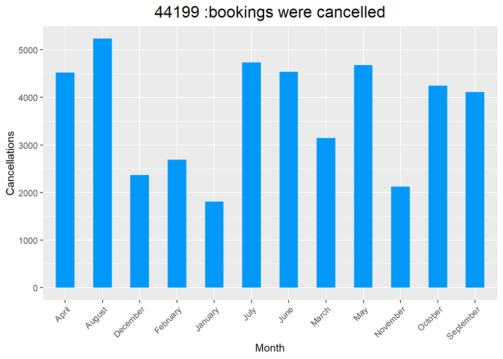

```r
# Plotting the chart
ggplot(source1_df, aes(x = arrival_date_month, y = is_canceled)) +
  geom_col(
    stat="identity", width=0.5, fill = "#0099f9"
  ) +
  labs(
    title = title1,
    x = "Month",
    y = "Cancellations"
  ) +
  theme(
    plot.title = element_text(hjust = 0.5, size=16, family="Times New Roman"),
    axis.text.x = element_text(angle = 45, hjust = 1)
  )
```

```r
# 2. What was the booking ratio between resort hotel and city hotel?
# ---
# Barplot of booking ratio between resort hotel and city hotel

#install.packages("sqldf")
library(sqldf)
sub1_df <- sqldf("SELECT hotel, count(hotel) as bookings  FROM source1_df GROUP BY hotel")
sub1_df
```

```
##          hotel bookings
## 1   City Hotel    79163
## 2 Resort Hotel    40047
```

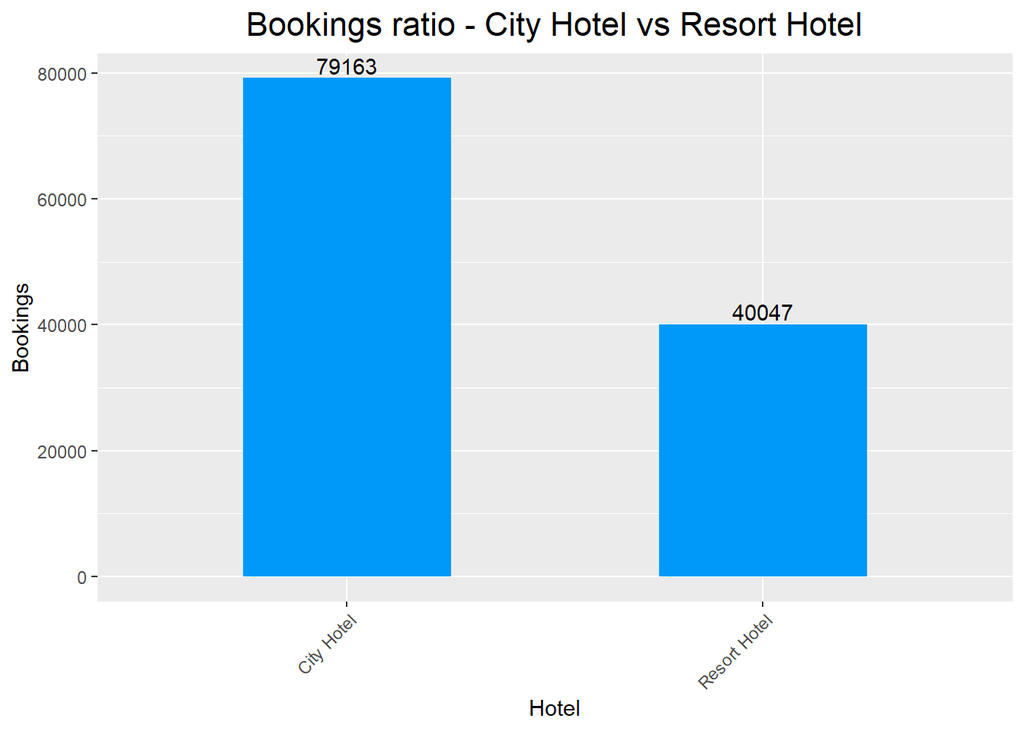

```r
# Plotting the chart
ggplot(sub1_df, aes(x = hotel, y = bookings)) +
  geom_col(
    stat="identity", width=0.5, fill = "#0099f9"
  ) +
  geom_text(aes(label=bookings), position=position_dodge(width=0.9), vjust=-0.25) +
  labs(
    title = "Bookings ratio - City Hotel vs Resort Hotel",
    x = "Hotel",
    y = "Bookings"
  ) +
  theme(
    plot.title = element_text(hjust = 0.5, size=16, family="Times New Roman"),
    axis.text.x = element_text(angle = 45, hjust = 1)
  )
```

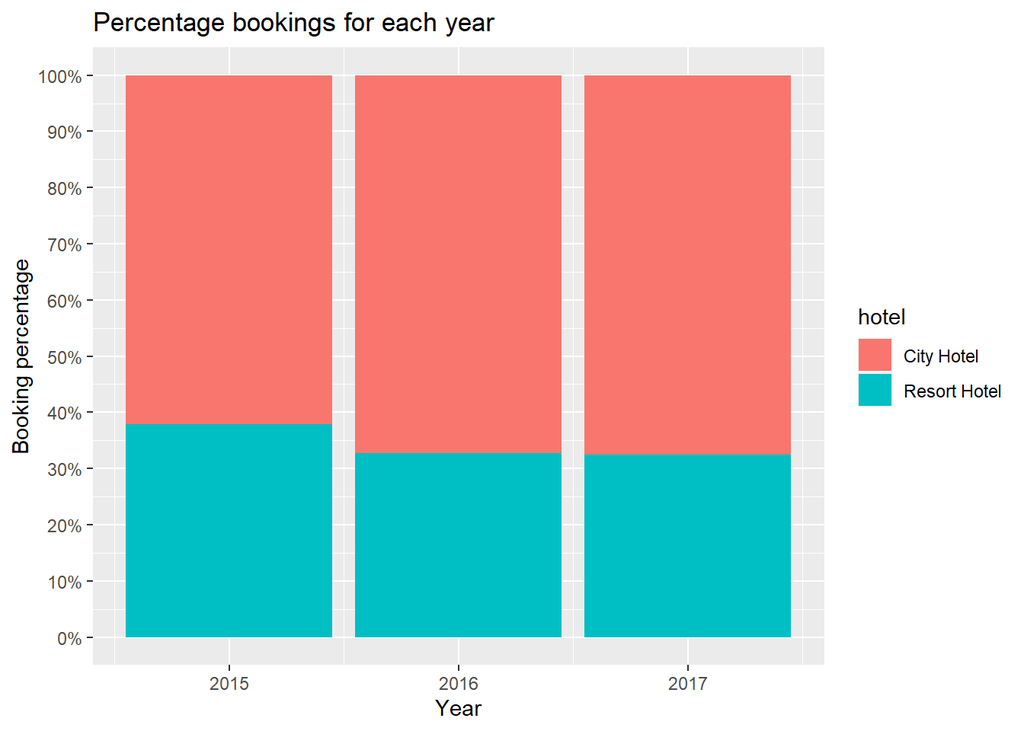

```r
# 3. What was the percentage of booking for each year?
# ---
#

#sum1 <- length(which(source1_df$is_canceled ==1))
sum1 <- length(source1_df$is_canceled)

# Stacked + percent
ggplot(source1_df, aes(fill=hotel, y=sum1, x=arrival_date_year)) +
    geom_bar(position="fill", stat="identity") +
    scale_y_continuous(labels = scales::percent,
                     breaks = scales::pretty_breaks(n = 8)) +
    labs(
    title = "Percentage bookings for each year",
    x = "Year",
    y = "Booking percentage"
  )
```

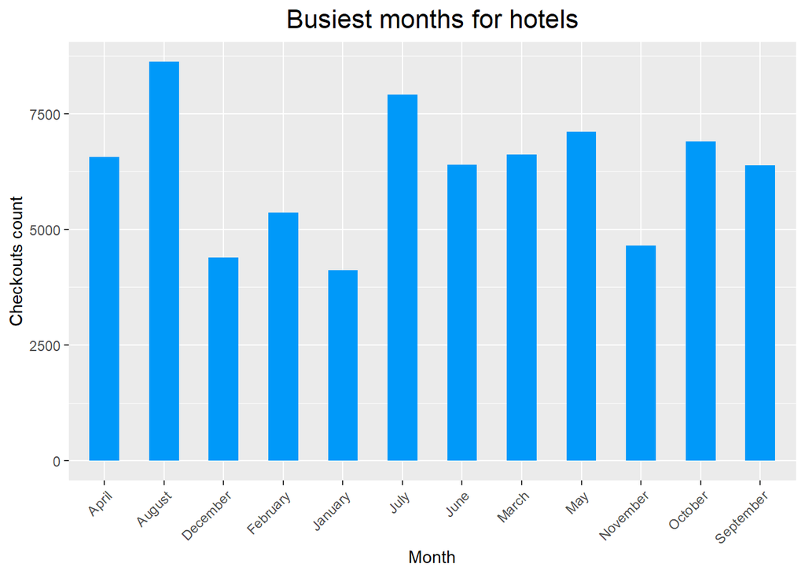

```r
# 4. Which were the most busiest months for hotels?
# ---
#



subs2_df <- sqldf("SELECT count(reservation_status) as checkouts, arrival_date_month as month FROM source1_df WHERE reservation_status == 'Check-Out' GROUP BY arrival_date_month")

#subs2_df

# Plotting the chart
ggplot(subs2_df, aes(x = month, y = checkouts)) +
  geom_col(
    stat="identity", width=0.5, fill = "#0099f9"
  ) +
  labs(
    title = "Busiest months for hotels",
    x = "Month",
    y = "Checkouts count"
  ) +
  theme(
    plot.title = element_text(hjust = 0.5, size=16, family="Times New Roman"),
    axis.text.x = element_text(angle = 45, hjust = 1)
  )
```

```r
# 5. From which top 3 countries did most guests come from?
# ---
# YOUR GOES BELOW
#

subs3_df <- sqldf("SELECT country, count(country) as cnt1 FROM source1_df GROUP BY country ORDER BY cnt1 DESC LIMIT 5")
subs3_df
```

```
##   country  cnt1
## 1     PRT 48483
## 2     GBR 12120
## 3     FRA 10401
## 4     ESP  8560
## 5     DEU  7285
```

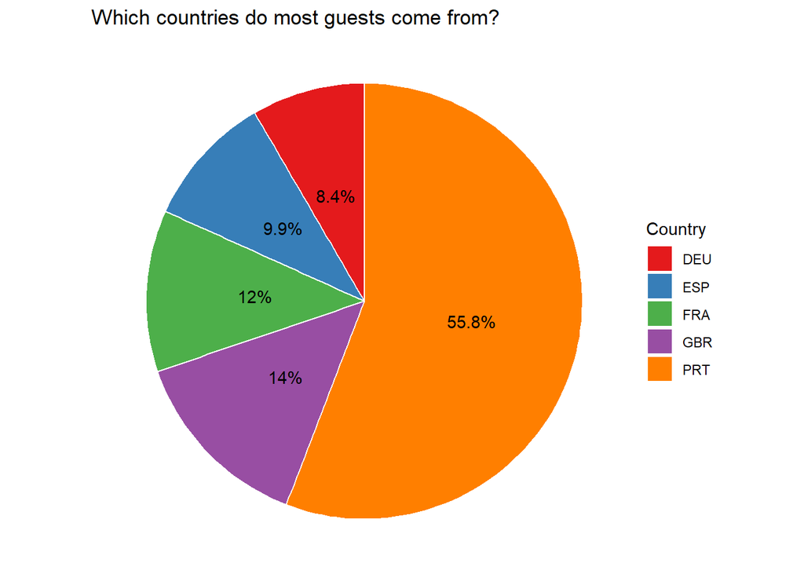

```r
# Plotting and styling
ggplot(data=subs3_df, aes(x="", y=cnt1, fill=country)) +
  geom_bar(
    stat="identity", width=0.5, color = "white"
  ) +
  coord_polar("y") +
  geom_text(
    aes(label = paste0(round(cnt1 / sum(cnt1) * 100, 1), "%")), position = position_stack(vjust = 0.5)
  ) +
  scale_fill_brewer(palette="Set1") +
  labs(
    fill = "Country",
    title = "Which countries do most guests come from?"
  ) +
  theme_void()
```

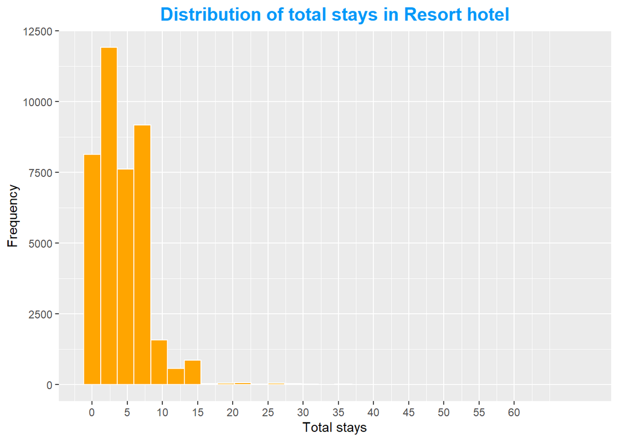

```r
# 6.a) How long do most people stay in hotels?
#   b) By city and resort? Separate the data by hotel
# ---
#

subs4_df <- sqldf("SELECT (stays_in_weekend_nights + stays_in_week_nights) as totalstays FROM source1_df WHERE hotel == 'Resort Hotel'")
#subs4_df

subs5_df <- sqldf("SELECT (stays_in_weekend_nights + stays_in_week_nights) as totalstays FROM source1_df WHERE hotel == 'City Hotel'")
#subs5_df


ggplot(subs4_df, aes(x = totalstays)) +
  geom_histogram(
    bins=30, fill = "orange", color = "white"
  ) +
  scale_x_continuous(breaks = seq(0,60,5))+
  labs(
    title = "Distribution of total stays in Resort hotel",
    x = "Total stays",
    y ="Frequency"
  ) +
  theme(
    plot.title = element_text(color = "#0099f9", size = 15, face = "bold", hjust = 0.5),
  )
```

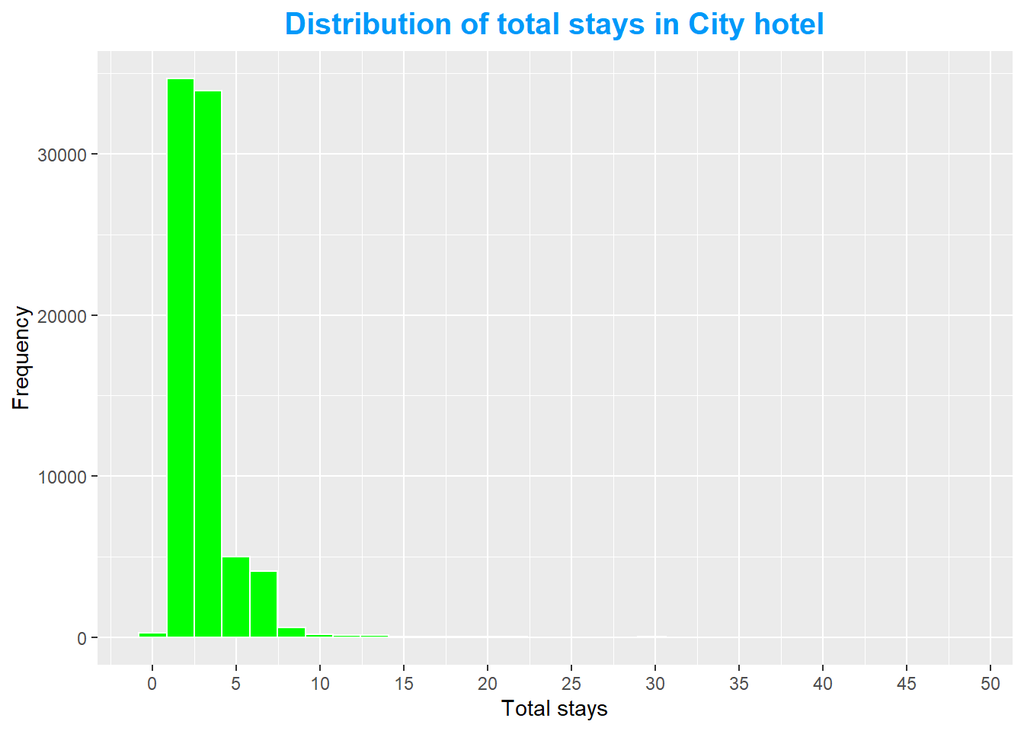

```r
ggplot(subs5_df, aes(x = totalstays)) +
  geom_histogram(
    bins=30, fill = "green", color = "white"
  ) +
  scale_x_continuous(breaks = seq(0,60,5))+
  labs(
    title = "Distribution of total stays in City hotel",
    x = "Total stays",
    y ="Frequency"
  ) +
  theme(
    plot.title = element_text(color = "#0099f9", size = 15, face = "bold", hjust = 0.5),
  )
```

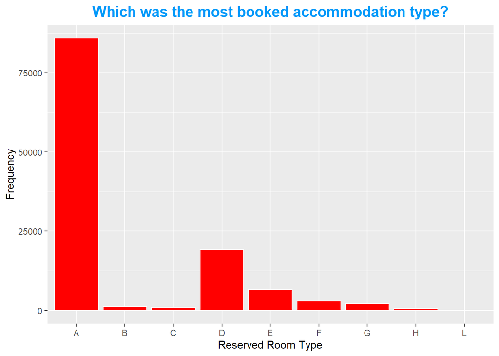

```r
# 7. Which was the most booked accommodation type (Single, Couple, Family)?
# ---
#

ggplot(source1_df, aes(x = reserved_room_type)) +
  geom_histogram(
    bins=20, fill = "red", color = "white", stat="count"
  ) +
  labs(
    title = "Which was the most booked accommodation type?",
    x = "Reserved Room Type",
    y ="Frequency"
  ) +
  theme(
    plot.title = element_text(color = "#0099f9", size = 15, face = "bold", hjust = 0.5),
  )
```

### 5.b) Recommendations

From the above analysis, below are our recommendations:

- Bulk of bookings come from 3 countries [PRT, GBR, FRA]. Greater investment in marketing and promotion in this 3 countries will boost revenue
- Most popular reserved room types are A and D. Room Types B,C,F,G,H,L have such low demand that management should consid converting them to room types A,D or E
- The busiest months are July and August. Hotels staffing and resourcing during these months should be optimized to cater for surges in demand with no reduction in service quality due to high customer traffic
- City Hotels have significantly more bookings than resort hotels. Core business functions should be focused more on the City Hotel side of business than the Resorts

## 6. Challenging your Solution

In this step, we review our solution and implement approaches that could potentially provide a better outcome. In our case, we could propose the following question that wasn’t answered in our solution because it couldn’t have greatly contributed to our recommendation.

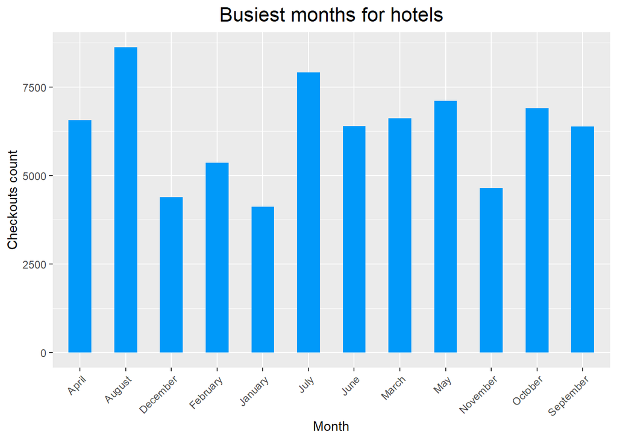

```r
# When should hotels provide special offers?
# ---
# YOUR GOES BELOW
#

# Plotting the chart
ggplot(subs2_df, aes(x = month, y = checkouts)) +
  geom_col(
    stat="identity", width=0.5, fill = "#0099f9"
  ) +
  labs(
    title = "Busiest months for hotels",
    x = "Month",
    y = "Checkouts count"
  ) +
  theme(
    plot.title = element_text(hjust = 0.5, size=16, family="Times New Roman"),
    axis.text.x = element_text(angle = 45, hjust = 1)
  )
```

## 7. Follow up questions

During this step, you rethink and propose other ways that you can improve your solution.

a). Did we have the right data? …Yes, we had the right data b). Do we need other data to answer our question?… No, we were able to advise management on best methods to boost sales/revenues c). Did we have the right question?…Yes, the research questions helped in providing recommendations to management